# Relatório Final

### Notebook do Trabalho Definição de Dataset Limpeza, Análise dos Dados e Modelagem

ALUNO: Emerson Adam CDA - UTFPR

# Definição do Dataset

# Algumas perguntas sobre o dataset - EDA

Quais são os tipos de registros mais comuns em Curitiba?

Quais os dias da semana possuem mais registros?

Quais bairros possuem mais registros?

Qual a distribuição das ocorrências nos anos?

Qual o dia onde há o maior numero de registros referente à perturbação de sossego?

Qual o período do dia em que há maior registros referente à perturbação de sossego?

# Hipótese - Modelagem

Nota-se que há um aumento nos registros iniciando em 2019, voltando a diminuir em 2022. Periodo da pandemia da Covid-19. Existe relaçao entre a pandemia e o aumento de registros?

```python
import pandas as pd
import scipy.stats as stats
import matplotlib.pyplot as plt
#importando dataset em um dataframe utilizando Pandas
df = pd.read_csv('../trabalho/data/2023-04-01_sigesguarda_-_Base_de_Dados.csv', sep=';', encoding='ANSI',low_memory=False)
```

```python
#olhando os primeiros 10 registros do dataframe
df.head(100)
```

|  | ATENDIMENTO_ANO | ATENDIMENTO_BAIRRO_NOME | EQUIPAMENTO_URBANO_NOME | FLAG_EQUIPAMENTO_URBANO | FLAG_FLAGRANTE | LOGRADOURO_NOME | NATUREZA1_DEFESA_CIVIL | NATUREZA1_DESCRICAO | NATUREZA2_DEFESA_CIVIL | NATUREZA2_DESCRICAO | ... | OCORRENCIA_HORA | OCORRENCIA_MES | OPERACAO_DESCRICAO | ORIGEM_CHAMADO_DESCRICAO | REGIONAL_FATO_NOME | SECRETARIA_NOME | SECRETARIA_SIGLA | SERVICO_NOME | SITUACAO_EQUIPE_DESCRICAO | NUMERO_PROTOCOLO_156 |
| --- | --- | --- | --- | --- | --- | --- | --- | --- | --- | --- | --- | --- | --- | --- | --- | --- | --- | --- | --- | --- | --- |
| 0 | --------------- | ----------------------- | ----------------------------------------------... | ----------------------- | -------------- | ----------------------------------------------... | ---------------------- | ----------------------------------------------... | ---------------------- | ----------------------------------------------... | ... | --------------- | -------------- | ----------------------------------------------... | ----------------------------------------------... | -------------------- | ----------------------------------------------... | ---------------- | ----------------------------------------------... | ----------------------------------------------... | -------------------- |
| 1 | 2009 | CIDADE INDUSTRIAL | NaN | NÃO | NÃO | DAVI XAVIER DA SILVA | 0 | Alarmes | NaN | NaN | ... | 15:14:00 | 1 | NaN | . | CIC | FUNDAÇÃO DE AÇÃO SOCIAL | FAS | SIGA | NaN | NaN |
| 2 | 2009 | FAZENDINHA | BOSQUE DA FAZENDINHA | SIM | NÃO | CARLOS KLEMTZ | 0 | Roubo | NaN | NaN | ... | 15:22:00 | 1 | NaN | 153 | PORTÃO | SECRETARIA MUNICIPAL MEIO AMBIENTE | SMMA | NORMAL | NaN | NaN |
| 3 | 2009 | UBERABA | NaN | NÃO | NÃO | DOUTOR JOÃO DE PAULA MOURA BRITO | 0 | Animais | NaN | NaN | ... | 15:59:00 | 1 | NaN | 156 | CAJURU | SECRETARIA MUNICIPAL DA SAÚDE | SMS | SACAF | NaN | 2640856 |
| 4 | 2009 | SÍTIO CERCADO | NaN | NÃO | NÃO | EDGARD CAVALCANTI DE ALBUQUERQUE | 0 | Animais | NaN | NaN | ... | 16:13:00 | 1 | NaN | 156 | BAIRRO NOVO | SECRETARIA MUNICIPAL DA SAÚDE | SMS | SACAF | NaN | 2640854 |
| ... | ... | ... | ... | ... | ... | ... | ... | ... | ... | ... | ... | ... | ... | ... | ... | ... | ... | ... | ... | ... | ... |
| 95 | 2009 | BOA VISTA | NaN | NÃO | NÃO | BRIGADEIRO ARTHUR CARLOS PERALTA | 1 | Alagamento | NaN | NaN | ... | 16:51:00 | 1 | NaN | 156 | BOA VISTA | SECRETARIA MUNICIPAL DE DEFESA SOCIAL E TRANSITO | SMDT | NORMAL | NaN | NaN |
| 96 | 2009 | REBOUÇAS | NaN | NÃO | NÃO | MARECHAL FLORIANO PEIXOTO | 1 | Alagamento | NaN | NaN | ... | 16:51:00 | 1 | NaN | 156 | MATRIZ | SECRETARIA MUNICIPAL DE DEFESA SOCIAL E TRANSITO | SMDT | NORMAL | NaN | NaN |
| 97 | 2009 | FAZENDINHA | NaN | NÃO | NÃO | PINHEIRO MACHADO | 1 | Alagamento | NaN | NaN | ... | 16:51:00 | 1 | NaN | 156 | PORTÃO | SECRETARIA MUNICIPAL DE DEFESA SOCIAL E TRANSITO | SMDT | NORMAL | NaN | NaN |
| 98 | 2009 | TATUQUARA | NaN | NÃO | NÃO | ELIAS CASSEB | 1 | Alagamento | NaN | NaN | ... | 17:50:00 | 1 | NaN | 199 | PINHEIRINHO | SECRETARIA MUNICIPAL DE DEFESA SOCIAL E TRANSITO | SMDT | NORMAL | NaN | NaN |
| 99 | 2009 | PINHEIRINHO | NaN | NÃO | NÃO | ELIAS CASSEB | 1 | Alagamento | NaN | NaN | ... | 17:50:00 | 1 | NaN | 199 | PINHEIRINHO | SECRETARIA MUNICIPAL DE DEFESA SOCIAL E TRANSITO | SMDT | NORMAL | NaN | NaN |

100 rows × 35 columns

```python
#Olhando alguns dados estatisticos sobre o dataframe criado
df.describe()
```

|  | ATENDIMENTO_ANO | ATENDIMENTO_BAIRRO_NOME | EQUIPAMENTO_URBANO_NOME | FLAG_EQUIPAMENTO_URBANO | FLAG_FLAGRANTE | LOGRADOURO_NOME | NATUREZA1_DEFESA_CIVIL | NATUREZA1_DESCRICAO | NATUREZA2_DEFESA_CIVIL | NATUREZA2_DESCRICAO | ... | OCORRENCIA_HORA | OCORRENCIA_MES | OPERACAO_DESCRICAO | ORIGEM_CHAMADO_DESCRICAO | REGIONAL_FATO_NOME | SECRETARIA_NOME | SECRETARIA_SIGLA | SERVICO_NOME | SITUACAO_EQUIPE_DESCRICAO | NUMERO_PROTOCOLO_156 |
| --- | --- | --- | --- | --- | --- | --- | --- | --- | --- | --- | --- | --- | --- | --- | --- | --- | --- | --- | --- | --- | --- |
| count | 429328 | 429202 | 152087 | 429347 | 429347 | 429347 | 429347 | 429347 | 22175 | 22175 | ... | 429347 | 429347 | 317124 | 429347 | 429336 | 429347 | 429347 | 429347 | 303670 | 12346 |
| unique | 15 | 193 | 3786 | 3 | 3 | 19120 | 3 | 189 | 3 | 167 | ... | 1441 | 13 | 22 | 33 | 15 | 39 | 39 | 32 | 4 | 12345 |
| top | 2021 | CENTRO | PARQUE BARIGUI | NÃO | NÃO | MARECHAL FLORIANO PEIXOTO | 0 | Apoio | 0 | Apoio | ... | 15:00:00 | 3 | NORMAL | 153 | MATRIZ | SECRETARIA MUNICIPAL DE DEFESA SOCIAL E TRANSITO | SMDT | NORMAL | Solicitação | 2758909 |
| freq | 58726 | 73559 | 4362 | 277260 | 410150 | 7723 | 417971 | 69920 | 21731 | 3206 | ... | 2984 | 38840 | 300393 | 149571 | 134535 | 283173 | 283173 | 323524 | 219161 | 2 |

4 rows × 35 columns

```python
#olhando a quantidade de Linhas
df.shape[0]
```

```
429347
```

```python
#verificando todos as colunas existentes no DF
df.columns
```

```
Index(['ATENDIMENTO_ANO', 'ATENDIMENTO_BAIRRO_NOME', 'EQUIPAMENTO_URBANO_NOME',
       'FLAG_EQUIPAMENTO_URBANO', 'FLAG_FLAGRANTE', 'LOGRADOURO_NOME',
       'NATUREZA1_DEFESA_CIVIL', 'NATUREZA1_DESCRICAO',
       'NATUREZA2_DEFESA_CIVIL', 'NATUREZA2_DESCRICAO',
       'NATUREZA3_DEFESA_CIVIL', 'NATUREZA3_DESCRICAO',
       'NATUREZA4_DEFESA_CIVIL', 'NATUREZA4_DESCRICAO',
       'NATUREZA5_DEFESA_CIVIL', 'NATUREZA5_DESCRICAO',
       'SUBCATEGORIA1_DESCRICAO', 'SUBCATEGORIA2_DESCRICAO',
       'SUBCATEGORIA3_DESCRICAO', 'SUBCATEGORIA4_DESCRICAO',
       'SUBCATEGORIA5_DESCRICAO', 'OCORRENCIA_ANO', 'OCORRENCIA_CODIGO',
       'OCORRENCIA_DATA', 'OCORRENCIA_DIA_SEMANA', 'OCORRENCIA_HORA',
       'OCORRENCIA_MES', 'OPERACAO_DESCRICAO', 'ORIGEM_CHAMADO_DESCRICAO',
       'REGIONAL_FATO_NOME', 'SECRETARIA_NOME', 'SECRETARIA_SIGLA',
       'SERVICO_NOME', 'SITUACAO_EQUIPE_DESCRICAO', 'NUMERO_PROTOCOLO_156'],
      dtype='object')
```

```python
#olhando os tipos de atendimentos efetuados no período
df['NATUREZA1_DESCRICAO'].unique()
```

```
array(['----------------------------------------------------------------------------------------------------',
       'Alarmes', 'Roubo', 'Animais', 'Trânsito', 'Invasão', 'Apoio',
       'Fundada Suspeita (Abordagem)', 'Substância Ilícita',
       'Atitude Suspeita', 'Queda de árvore', 'Alagamento', 'Dano',
       'Veículo', 'Desinteligência', 'Rixa', 'Averiguação',
       'Uso indevido do cartão transporte', 'Orientação', 'Furto',
       'Desabamento', 'Risco de acidente/à vida (Defesa Civil)',
       'Bueiro entupido', 'Perturbação do sossego', 'Erosão', 'Ameaça',
       'Risco de desabamento / desmoronamento', 'Agressão física/verbal',
       'Pesca em local proibido', 'Desacato', 'Vias de fato',
       'Porte Ilegal', 'Risco de acidente / à vida', 'Depósito irregular',
       'Ataque de insetos', 'Proteção ao patrimônio', 'Destelhamento',
       'Extorsão', 'Queima a céu aberto',
       'Escrito ou objeto obsceno (panfletos pornográficos)',
       'Disparo de arma', 'Achado', 'Substância Lícita',
       'Atos obscenos/libidinosos', 'Incêndio', 'Escolta',
       'Lesão Corporal', 'Encaminhamento', 'Tentativa', 'Desaparecimento',
       'Banho em local impróprio',
       'Fornecimento de bebida alcoólica à menores',
       'Conduta inconveniente', 'Poluição visual/ambiental',
       'Criança perdida/desaparecida',
       'Risco de queda de fios de energia', 'Óbito',
       'Bueiro aberto/sem tampa', 'Embriaguez', 'Vadiagem', 'Ronda',
       'Abandono de incapaz', 'Peculato', 'Maus tratos à pessoas',
       'Situação de risco', 'Suicídio', 'Apologia de crime ou criminoso',
       'Favorecimento da prostituição', 'Paciente/usuário alterado',
       'Corte irregular de árvore', 'Vistoria', 'Fuga de aluno/interno',
       'Explosão', 'Manifestação', 'Risco de queda de galho',
       'Averiguação (Defesa Civil)', 'Queda de poste', 'Crime ambiental',
       'Vazamento ou derramamento de Produto Perigoso ou Infectante',
       'Importunação\xa0sexual', 'Calote', 'Moeda Falsa',
       'Obstrução de via', 'Retirada de invasão', 'Comércio ambulante',
       'AIFU', 'Jogo de Azar', 'Abuso de incapazes', 'Infiltração',
       'Fiscalizações e Orientações', 'Atentado violento ao pudor',
       'Construção Irregular', 'Homicídio', 'Saturação', 'Prostituição',
       'Desobediência', 'Denúncia de bomba', 'Afogamento',
       'Importunação ofensiva ao pudor', 'Menor gazeando aula',
       'Devolução de coisa achada', 'Estupro', 'Estelionato',
       'Falsidade ideológica (Falsa Identidade)',
       'Constrangimento ilegal', 'Calúnia', 'Queda de fios de energia',
```

[output cut: 28 more lines]

```
       'Rompimento de Barragem', 'Omissão de socorro',
       'Fornecimento de Lona', 'Acidente Viatura',
       'Falsificação de documento Publico', 'Quadrilha ou bando',
       'Liberação de pessoa presa/apreendida por recusa no recebimento pela DP',
       'Fuga de paciente', 'Maus tratos a animais', 'Trote Telefonico',
       'RECUSAR SE IDENTIFICAR AO POLICIAL', 'Denuncia Improcedente',
       'ZELADORIA URBANA', 'Descumprimento lei 15799/2021 COVID-19',
       'Câmera Off-Line', 'Perseguição (stalking)', 'Incitação ao crime',
       'Ataque cão feroz', 'Extravio de Equipamento',
       'Averiguação (COSEDI)', 'Incendio/Explosão em edificação',
       'Queda de Revestimento de Fachadas',
       'Desabamento de Telhado/Cobertura', 'Queda de Muro',
       'Prevaricação', 'Patrulha Maria da Penha',
       'Obstrução da Atividade Policial', 'Afundamento de Piso'],
      dtype=object)
```

```python
#identificado quais colunas iremos trabalhar iremos agora ajustar o modelo em um novo dataframe para trabalho.
#Vamos selecionar somente as colunas abaixo

df_filtrado = df[['ATENDIMENTO_BAIRRO_NOME','LOGRADOURO_NOME','NATUREZA1_DESCRICAO','SUBCATEGORIA1_DESCRICAO','OCORRENCIA_ANO','OCORRENCIA_CODIGO','OCORRENCIA_DATA','OCORRENCIA_DIA_SEMANA','OCORRENCIA_HORA','OCORRENCIA_MES','OPERACAO_DESCRICAO','ORIGEM_CHAMADO_DESCRICAO']]
```

```python
#apagando todas as linhas onde o tipo de registro é nulo na coluna Natureza1_descrição
df_filtrado = df_filtrado.dropna(subset=['NATUREZA1_DESCRICAO'])
df_filtrado
#Retorna a mesma quantidade de linhas do dataframe original, indicando que todos os registros possuem uma classificação
```

|  | ATENDIMENTO_BAIRRO_NOME | LOGRADOURO_NOME | NATUREZA1_DESCRICAO | SUBCATEGORIA1_DESCRICAO | OCORRENCIA_ANO | OCORRENCIA_CODIGO | OCORRENCIA_DATA | OCORRENCIA_DIA_SEMANA | OCORRENCIA_HORA | OCORRENCIA_MES | OPERACAO_DESCRICAO | ORIGEM_CHAMADO_DESCRICAO |
| --- | --- | --- | --- | --- | --- | --- | --- | --- | --- | --- | --- | --- |
| 0 | ----------------------- | ----------------------------------------------... | ----------------------------------------------... | ----------------------------------------------... | -------------- | ----------------- | ----------------------- | --------------------- | --------------- | -------------- | ----------------------------------------------... | ----------------------------------------------... |
| 1 | CIDADE INDUSTRIAL | DAVI XAVIER DA SILVA | Alarmes | Disparo de Alarme (violação) | 2009 | 1 | 2009-01-01 15:14:00.000 | QUINTA | 15:14:00 | 1 | NaN | . |
| 2 | FAZENDINHA | CARLOS KLEMTZ | Roubo | Transeunte | 2009 | 2 | 2009-01-01 15:22:00.000 | QUINTA | 15:22:00 | 1 | NaN | 153 |
| 3 | UBERABA | DOUTOR JOÃO DE PAULA MOURA BRITO | Animais | Cão solto em via pública | 2009 | 3 | 2009-01-01 15:59:00.000 | QUINTA | 15:59:00 | 1 | NaN | 156 |
| 4 | SÍTIO CERCADO | EDGARD CAVALCANTI DE ALBUQUERQUE | Animais | Cão solto em via pública | 2009 | 4 | 2009-01-01 16:13:00.000 | QUINTA | 16:13:00 | 1 | NaN | 156 |
| ... | ... | ... | ... | ... | ... | ... | ... | ... | ... | ... | ... | ... |
| 429342 | PORTÃO | REPÚBLICA ARGENTINA | Ameaça | NaN | 2022 | 429808 | 2022-12-12 06:09:00.000 | SEGUNDA | 06:09:00 | 12 | NORMAL | 153 |
| 429343 | SÍTIO CERCADO | RICARDO GASPARIAN MACHADO | Roubo | Transporte Coletivo | 2022 | 429809 | 2022-12-12 06:26:00.000 | SEGUNDA | 06:26:00 | 12 | NORMAL | 153 |
| 429344 | JARDIM BOTÂNICO | SETE DE SETEMBRO | Apoio | Apoio ao GM | 2022 | 429810 | 2022-12-12 06:28:00.000 | SEGUNDA | 06:28:00 | 12 | NORMAL | 153 |
| 429345 | JARDIM BOTÂNICO | SETE DE SETEMBRO | Avaria em Equipamento/Patrimônio (não intencio... | NaN | 2022 | 429811 | 2022-12-12 06:35:00.000 | SEGUNDA | 06:35:00 | 12 | NORMAL | IMEDIATA |
| 429346 | XAXIM | BR-476 | Importunação sexual | NaN | 2022 | 429812 | 2022-12-12 07:21:00.000 | SEGUNDA | 07:21:00 | 12 | NORMAL | 153 |

429347 rows × 12 columns

```python
#Vamos responder agora a primeira pergunta, qual o tipo mais comum de registro?
df['NATUREZA1_DESCRICAO'].value_counts()
```

```
Apoio                           69920
Fundada Suspeita (Abordagem)    43426
Dano                            37826
Trânsito                        34628
Orientação                      26465
                                ...
Rompimento de Barragem              1
Óbito (Defesa Civil)                1
Rufianismo                          1
Corrupção ativa                     1
Afundamento de Piso                 1
Name: NATUREZA1_DESCRICAO, Length: 189, dtype: int64
```

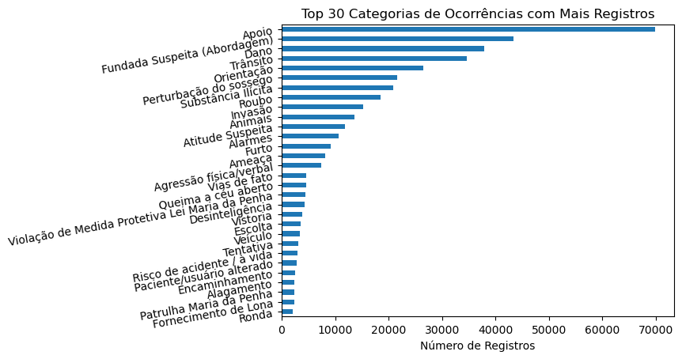

```python
#colocando isto em um gráfico de barras

df_top30_reg= df_filtrado['NATUREZA1_DESCRICAO'].value_counts().sort_values(ascending=False).head(30)
df_top30_reg.sort_values(ascending=True).plot.barh(rot=10)
plt.xlabel('Número de Registros')
plt.title('Top 30 Categorias de Ocorrências com Mais Registros')
plt.show()
```

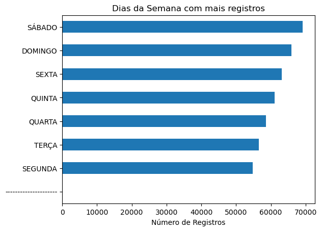

```python
#vamos agora responder a segunda pergunta Quais os dias da semana possuem mais registros?
df['OCORRENCIA_DIA_SEMANA'].value_counts(ascending=True).plot.barh()
plt.xlabel('Número de Registros')
plt.title('Dias da Semana com mais registros')
plt.show()
```

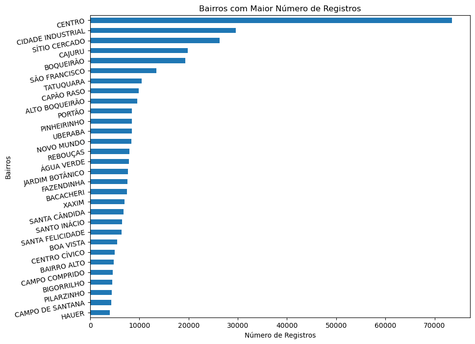

```python
#vamos agora responder a terceira pergunta. Quais bairros possuem mais registros?
df_top30_bairros= df_filtrado['ATENDIMENTO_BAIRRO_NOME'].value_counts().sort_values(ascending=False).head(30)

gr_top30_bairros = df_top30_bairros.sort_values(ascending=True).plot.barh(rot=10, figsize=(10, 8))
gr_top30_bairros.set_xlabel('Número de Registros')
gr_top30_bairros.set_ylabel('Bairros')
gr_top30_bairros.set_title('Bairros com Maior Número de Registros')
plt.show()
```

```python
df_filtrado.info('OCORRENCIA_ANO')
```

```
<class 'pandas.core.frame.DataFrame'>
RangeIndex: 429347 entries, 0 to 429346
Data columns (total 12 columns):
 #   Column                    Non-Null Count   Dtype
---  ------                    --------------   -----
 0   ATENDIMENTO_BAIRRO_NOME   429202 non-null  object
 1   LOGRADOURO_NOME           429347 non-null  object
 2   NATUREZA1_DESCRICAO       429347 non-null  object
 3   SUBCATEGORIA1_DESCRICAO   298245 non-null  object
 4   OCORRENCIA_ANO            429347 non-null  object
 5   OCORRENCIA_CODIGO         429347 non-null  object
 6   OCORRENCIA_DATA           429347 non-null  object
 7   OCORRENCIA_DIA_SEMANA     429347 non-null  object
 8   OCORRENCIA_HORA           429347 non-null  object
 9   OCORRENCIA_MES            429347 non-null  object
 10  OPERACAO_DESCRICAO        317124 non-null  object
 11  ORIGEM_CHAMADO_DESCRICAO  429347 non-null  object
dtypes: object(12)
memory usage: 39.3+ MB
```

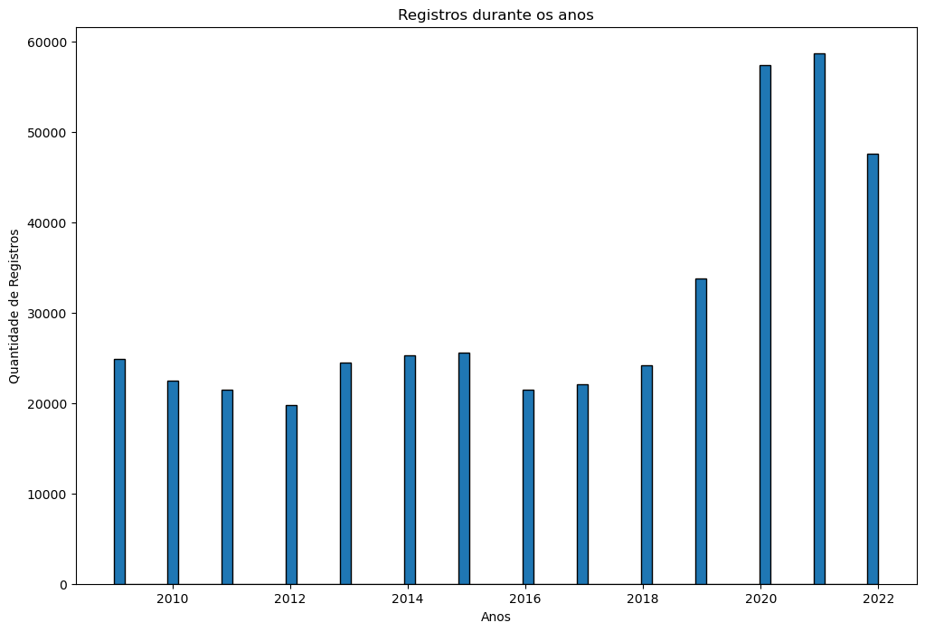

```python
#Limpando a valores inadequados
df_filtrado['OCORRENCIA_ANO'].unique()
df_filtrado = df_filtrado[df_filtrado['OCORRENCIA_ANO'] != '--------------']
#convertendo o tipo de dado para int
df_filtrado['OCORRENCIA_ANO'] = df_filtrado['OCORRENCIA_ANO'].astype(int)
#Colocando num boxplot a distribuiçao dos registros em todo o período.
#bx_reg_ano = df_filtrado.boxplot(column=['OCORRENCIA_ANO'], figsize=(12,8))
#bx_reg_ano.set_xlabel('')
#bx_reg_ano.set_ylabel('Anos')
#bx_reg_ano.set_title('Distribuição das ocorrências no período')

#Colocando num histograma a distribuiçao dos registros em todo o período - Recomendação do Professor Luiz
plt.figure(figsize=(12, 8))
plt.hist(df_filtrado['OCORRENCIA_ANO'], bins='auto', edgecolor='black')
plt.xlabel('Anos')
plt.ylabel('Quantidade de Registros')
plt.title('Registros durante os anos')
plt.show()
```

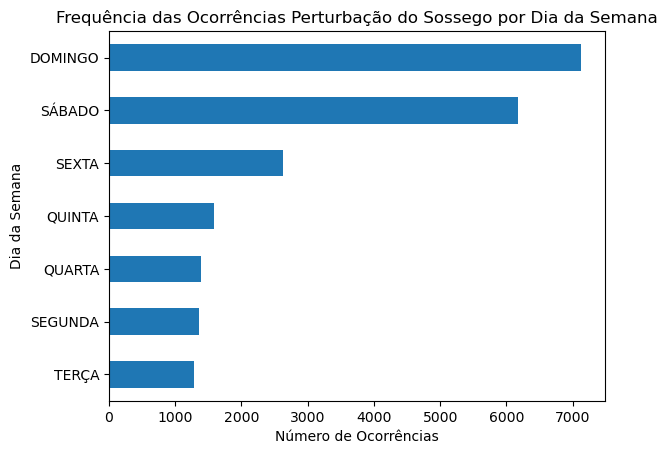

```python
df_perturbacao = df_filtrado[df_filtrado['NATUREZA1_DESCRICAO'] == 'Perturbação do sossego']
df_perturbacao_dia_semana = df_perturbacao.groupby('OCORRENCIA_DIA_SEMANA')['NATUREZA1_DESCRICAO'].count().sort_values(ascending=True)
gr_per_dia_semana = df_perturbacao_dia_semana.plot.barh()
gr_per_dia_semana.set_xlabel('Número de Ocorrências')
gr_per_dia_semana.set_ylabel('Dia da Semana')
gr_per_dia_semana.set_title('Frequência das Ocorrências Perturbação do Sossego por Dia da Semana')
plt.show()
```

[figure not shown]

```python
df_perturbacao = df_filtrado[df_filtrado['NATUREZA1_DESCRICAO'] == 'Perturbação do sossego']
df_perturbacao_horario = df_perturbacao.groupby('OCORRENCIA_HORA')['NATUREZA1_DESCRICAO'].count().sort_values(ascending=False)
df_perturbacao_horario.plot.barh()
#nao ficou muito boa a visualização, vamos separar os horarios em 4 periodos, manhã, tarde, noite e madrugada
```

```python
#para realizar isto, precisamos converter a coluna ocorrencia_hora no formato datetime usando pandas
df_filtrado['OCORRENCIA_HORA'] = pd.to_datetime(df_filtrado['OCORRENCIA_HORA'], format='%H:%M:%S')


# utilizar função para criar nova coluna 'PERIODO_DIA'
def get_period(hour):
    if hour < 6:
        return 'Madrugada'
    elif hour < 12:
        return 'Manhã'
    elif hour < 18:
        return 'Tarde'
    else:
        return 'Noite'

df_filtrado['PERIODO_DIA'] = df_filtrado['OCORRENCIA_HORA'].apply(lambda x: get_period(x.hour))#funçao anonima em conjunto com metodo apply recebendo como parametro somente a hora e aplicando o periodo conforme regras da função acima

# verificar a nova coluna 'PERIODO_DIA'
df_filtrado['PERIODO_DIA']
```

```
1         Tarde
2         Tarde
3         Tarde
4         Tarde
5         Tarde
          ...
429342    Manhã
429343    Manhã
429344    Manhã
429345    Manhã
429346    Manhã
Name: PERIODO_DIA, Length: 429346, dtype: object
```

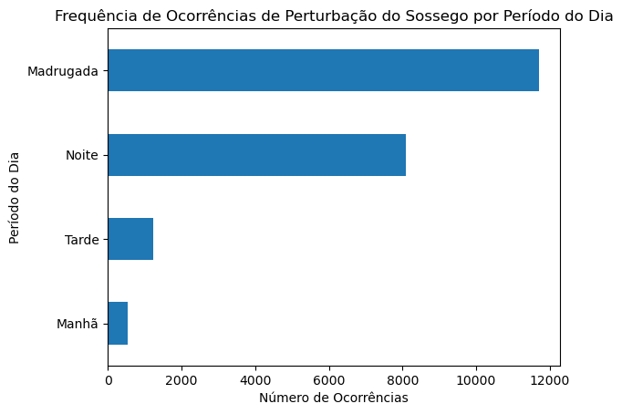

```python
# Agora sim, podemos fazer o grafico
df_perturbacao = df_filtrado[df_filtrado['NATUREZA1_DESCRICAO'] == 'Perturbação do sossego']#jogando novamente o DF com a nova coluna criada periodo_dia
df_perturbacao_horario2 = df_perturbacao.groupby('PERIODO_DIA')['NATUREZA1_DESCRICAO'].count().sort_values(ascending=True)

# Plotar o gráfico de barras horizontais
gr_per_periodo = df_perturbacao_horario2.plot.barh()
gr_per_periodo.set_xlabel('Número de Ocorrências')
gr_per_periodo.set_ylabel('Período do Dia')
gr_per_periodo.set_title('Frequência de Ocorrências de Perturbação do Sossego por Período do Dia')
plt.show()
```

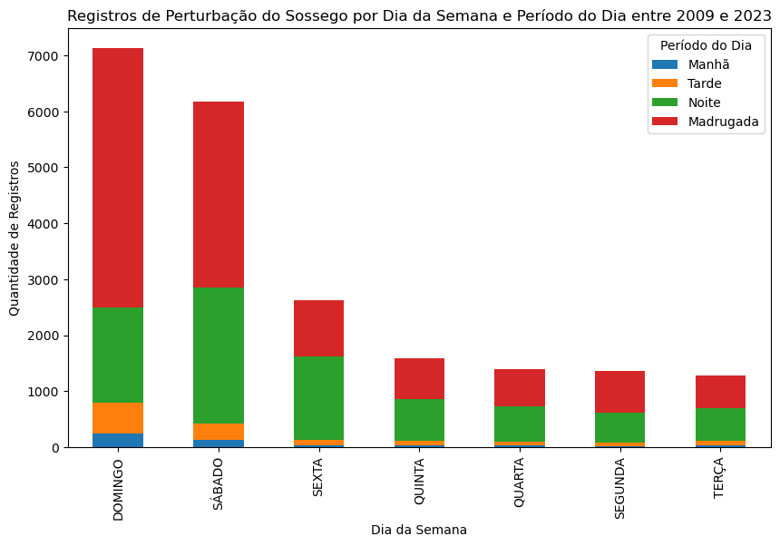

```python
# criando tabela dinâmica com a contagem de registros de perturbação por dia da semana e período do dia
table = pd.crosstab(index=df_perturbacao['OCORRENCIA_DIA_SEMANA'], columns=[df_perturbacao['PERIODO_DIA']], rownames=['Dia da Semana'], colnames=['Período do Dia'])

# Ordenar as colunas pela ordem dos períodos do dia
table = table[['Manhã', 'Tarde', 'Noite','Madrugada']]

# Ordenar as linhas pela quantidade de registros de perturbação do sossego em cada dia da semana, em ordem decrescente
table = table.loc[table.sum(axis=1).sort_values(ascending=False).index]

#Plot com legenda usanndo matplot
ax = table.plot(kind='bar', stacked=True, figsize=(10, 6))
ax.set_xlabel('Dia da Semana')
ax.set_ylabel('Quantidade de Registros')
ax.set_title('Registros de Perturbação do Sossego por Dia da Semana e Período do Dia entre 2009 e 2023')
plt.legend(title='Período do Dia', loc='upper right')
plt.show()
```

```python
#vamos agora criar testes para verificar se a hipotese de que o aumento de registros entre 2019 e 2022 possui correlação
#com a pandemia de Covid-19

#filtrando somente os registros entre 2019 e 2023
df_filtrado_1 = df_filtrado[(df_filtrado['OCORRENCIA_ANO'] >= 2019) & (df_filtrado['OCORRENCIA_ANO'] <= 2023)][['ATENDIMENTO_BAIRRO_NOME','LOGRADOURO_NOME','NATUREZA1_DESCRICAO','OCORRENCIA_ANO','OCORRENCIA_CODIGO','OCORRENCIA_DATA','OCORRENCIA_DIA_SEMANA','OCORRENCIA_HORA','OCORRENCIA_MES','OPERACAO_DESCRICAO','ORIGEM_CHAMADO_DESCRICAO']]
df_filtrado_1
#criando dataframe com os outros registros
df_filtrado_2 = df_filtrado[(df_filtrado['OCORRENCIA_ANO'] < 2018)][['ATENDIMENTO_BAIRRO_NOME','LOGRADOURO_NOME','NATUREZA1_DESCRICAO','OCORRENCIA_ANO','OCORRENCIA_CODIGO','OCORRENCIA_DATA','OCORRENCIA_DIA_SEMANA','OCORRENCIA_HORA','OCORRENCIA_MES','OPERACAO_DESCRICAO','ORIGEM_CHAMADO_DESCRICAO']]
df_filtrado_2
```

|  | ATENDIMENTO_BAIRRO_NOME | LOGRADOURO_NOME | NATUREZA1_DESCRICAO | OCORRENCIA_ANO | OCORRENCIA_CODIGO | OCORRENCIA_DATA | OCORRENCIA_DIA_SEMANA | OCORRENCIA_HORA | OCORRENCIA_MES | OPERACAO_DESCRICAO | ORIGEM_CHAMADO_DESCRICAO |
| --- | --- | --- | --- | --- | --- | --- | --- | --- | --- | --- | --- |
| 1 | CIDADE INDUSTRIAL | DAVI XAVIER DA SILVA | Alarmes | 2009 | 1 | 2009-01-01 15:14:00.000 | QUINTA | 1900-01-01 15:14:00 | 1 | NaN | . |
| 2 | FAZENDINHA | CARLOS KLEMTZ | Roubo | 2009 | 2 | 2009-01-01 15:22:00.000 | QUINTA | 1900-01-01 15:22:00 | 1 | NaN | 153 |
| 3 | UBERABA | DOUTOR JOÃO DE PAULA MOURA BRITO | Animais | 2009 | 3 | 2009-01-01 15:59:00.000 | QUINTA | 1900-01-01 15:59:00 | 1 | NaN | 156 |
| 4 | SÍTIO CERCADO | EDGARD CAVALCANTI DE ALBUQUERQUE | Animais | 2009 | 4 | 2009-01-01 16:13:00.000 | QUINTA | 1900-01-01 16:13:00 | 1 | NaN | 156 |
| 5 | TATUQUARA | CARLOS MUNHOZ DA ROCHA | Alarmes | 2009 | 5 | 2009-01-01 16:29:00.000 | QUINTA | 1900-01-01 16:29:00 | 1 | NaN | . |
| ... | ... | ... | ... | ... | ... | ... | ... | ... | ... | ... | ... |
| 207635 | ATUBA | REPÚBLICA GUARANI | Dano | 2017 | 207973 | 2017-12-31 18:38:00.000 | DOMINGO | 1900-01-01 18:38:00 | 12 | NORMAL | 153 |
| 207636 | CENTRO | EMILIANO PERNETA | Vistoria | 2017 | 207974 | 2017-12-31 21:18:00.000 | DOMINGO | 1900-01-01 21:18:00 | 12 | NORMAL | 153 |
| 207637 | ALTO BOQUEIRÃO | LUIZ MACHUCA | Alagamento | 2017 | 207975 | 2017-12-31 22:42:00.000 | DOMINGO | 1900-01-01 22:42:00 | 12 | NORMAL | 153 |
| 207638 | BOQUEIRÃO | CORONEL LUIZ JOSÉ DOS SANTOS | Animais | 2017 | 207976 | 2017-12-31 22:43:00.000 | DOMINGO | 1900-01-01 22:43:00 | 12 | NORMAL | 153 |
| 207639 | CIDADE INDUSTRIAL | EMÍLIO ROMANI | Dano | 2017 | 207977 | 2017-12-31 23:00:00.000 | DOMINGO | 1900-01-01 23:00:00 | 12 | NORMAL | G5 |

207639 rows × 11 columns